# Quality white wine predictor

- Summary
- Goal and Research Question
- Introduction
- Data
- Methods
- Analysis
  - Data Cleaning and Preprocessing
  - EDA first conclusions
  - Cross Validation and Hyperparameter tuning
  - Packages
- Results & Discussion
  - **Evaluation**
  - **Discussion**
- References

Authors: Nikita Shymberg, Aldo Saltao Barros, Yair Guterman, Son Chau

# Summary

This report trains a machine learning model to predict the quality of white wine based on physicochemical properties. Our models were trained on a white wine database from “vinho verde” containing 11 features and a target “quality”. Quality is a subjective measure, so the values in the dataset are the average grade of three experts. The quality of wine is a numeric property, so we trained regression models to predict this value ranging from 0 (very poor quality) to 10 (very high quality).

We trained several machine learning models and found that a KNN model with hyperparameters `"distance"` for `weights` and 25 neighbours performed best during cross validation. This model achieved a score of 0.54 on the test set.

# Goal and Research Question

This project aims to train a model to predict wine quality given measurable wine features.

# Introduction

According to experts, wine is differentiated according to its smell, flavour, and colour. Most people are not wine experts, so they cannot effectively determine that some wine is good or bad. The quality of a wine is important for consumers as well as the wine industry and it is determined by a very wide range of factors. For instance, industry players use product quality certifications to promote their products. Unfortunately, certification is a time-consuming process and requires assessment from human experts which makes it very expensive. Nowadays, it is possible to replace human tasks with machine learning models. In this case, a good wine quality predictor can be very useful in the certification process. For example, an automatic predictive system can be integrated into a decision support system, facilitating quality certification.

# Data

The wine quality dataset is publicly available on the UCI machine learning repository (links below). The dataset has two files, red wine and white wine variants of the Portuguese “Vinho Verde” wine. These datasets have been widely used by the machine learning community. The red wine dataset contains 1599 instances and the white wine dataset contains 4898 instances. We chose to focus solely on white wine because the white wine dataset has so many more records. Both files contain 11 input features and 1 output feature. Input features are based on the physicochemical tests and output variable based on sensory data is scaled in 11 quality classes from 0 to 10 (0-very bad to 10-very good)

- [UCI repository](https://archive.ics.uci.edu/ml/datasets/Wine+Quality)
- [White wine database](http://open.canada.ca/data/en/dataset/b374f60b-9580-44dc-83f6-c0a850c15f30)

Input variables:

1. **Alcohol**: the alcohol percentage of the wine
2. **Volatile acidity**: are high acetic acid in wine which leads to an unpleasant vinegar taste
3. **Sulphates**: a wine additive that contributes to SO2 levels and acts as an antimicrobial and antioxidant
4. **Citric Acid**: acts as a preservative to increase acidity (small quantities add freshness and flavor to wines)
5. **Total Sulfur Dioxide**: is the amount of free + bound forms of SO2
6. **Density**: sweeter wines have a higher density
7. **Chlorides**: the amount of salt in the wine
8. **Fixed acidity**: are non-volatile acids that do not evaporate readily
9. **pH**: the level of acidity
10. **Free Sulfur Dioxide**: it prevents microbial growth and the oxidation of wine
11. **Residual sugar**: is the amount of sugar remaining after fermentation stops. The key is to have a perfect balance between — sweetness and sourness (wines > 45g/ltrs are sweet)

# Methods

For this task, we used python’s scikit learn library (Pedregosa et al. 2011) to train the following models:

1. **DummyRegressor**: this is a baseline model that merely predicts the mean quality for each example without looking at any of the features. This should be the worst performing model.
2. **Ridge**: is a model tuning method that is used to analyse any data that suffers from multicollinearity. This method performs L2 regularization. When the issue of multicollinearity occurs, least-squares are unbiased, and variances are large, this results in predicted values to be far away from the actual values.
3. **Random Forest**: is an ensemble learning method for classification, regression and other tasks that operates by constructing a multitude of decision trees at training time. For classification tasks, the output of the random forest is the class selected by most trees. For regression tasks, the mean or average prediction of the individual trees is returned
4. **KNN**: is an approach to data classification that estimates how likely a data point is to be a member of one group or the other depending on what group the data points nearest to it are in.The k-nearest-neighbor is an example of a “lazy learner” algorithm, meaning that it does not build a model using the training set until a query of the data set is performed.
5. **Bayes**: is an algorithm that uses Bayes’ theorem to classify objects. Naive Bayes classifiers assume strong, or naive, independence between attributes of data points. Popular uses of naive Bayes classifiers include spam filters, text analysis and medical diagnosis.
6. **SVM**: is machine learning algorithm that analyzes data for classification and regression analysis. SVM is a supervised learning method that looks at data and sorts it into one of two categories. An SVM outputs a map of the sorted data with the margins between the two as far apart as possible.

# Analysis

### Data Cleaning and Preprocessing

The first step is to clean and prepare the data for analysis. Fortunately, this dataset is in great condition with no missing values and only numerical columns. The dataset was split up into two subsets: the training set and the test set with 80% of the data going into the training set and the rest into the test set. The training set will be used to train the models using cross-validation. The test set will only be used once to report the final scores for the best model.

### EDA first conclusions

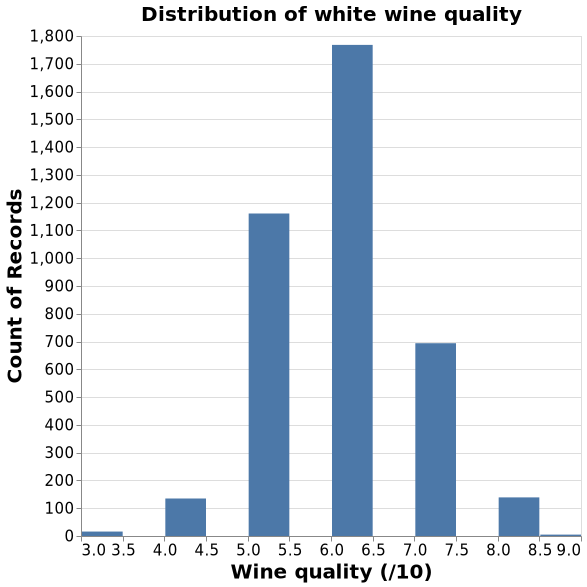

We also had a look at the distribution between individual features and the quality to see if there are any obvious features that clearly contribute to the quality. For instance, it appears that it *might* be the case that the higher the alcohol, sulphates, and ph levels the better the wine quality. We can check these information on the chart below:

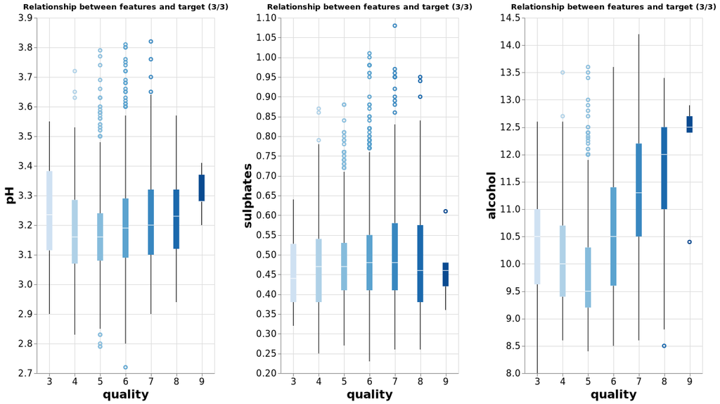

Following the same idea, there is some evidence that the smaller the chlorides, Free Sulfur Dioxide, total sulphur dioxide and density levels, the better the wine quality. The chart below ilustrates these findings:

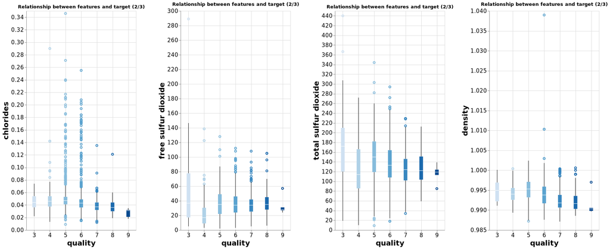

For some variables like fixed acidity, volatile acidity, citric acid and residual sugar seem to not influence wine quality on their own. However, we need to be careful with this statement since when these variables are combined with others, they might indeed influence wine quality. The chart below can shows these findings:

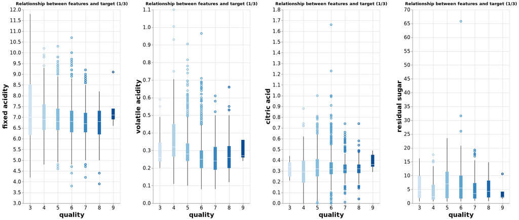

We also explored the correlations between the features. The heatmap below shows that some features are indeed correlated. In particular, we see a strong negative correlation between density and alcohol content. We also see a very positive correlation between density and residual sugar.

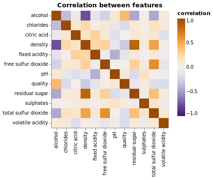

### Cross Validation and Hyperparameter tuning

In order to find the best model and perform hyperparameter optimization, we will use the cross validation approach to support our decision. Cross validation partitions the training set into 5 folds, trains the model on 4 of them, and evaluates the model on the reserved validation set. This process is repeated 5 times such that each fold acts as the validation fold once. Then, we will choose the model and hyperparameters with the best *R*<sup>2</sup> score.

The following hyperparameters were optimized:

DummyRegressor’s `strategy` was set to mean or median

Ridge’s `alpha` for L2 regularization

Random Forest’s `n_estimators` to set the number of trees. The `criterion` to set the criterion to split the nodes. The `max_depth` of the trees in the forest. Lastly, whether to use bootstrapping or not.

KNN’s `n_neighbors` to determine how many neighbours get to vote on the new datapoints score. The `weights` to determine whether closer points get a bigger vote than further away points.

Bayes’s `alpha_1`, `alpha_2`, `lambda_1`, and `lambda_2`.

SVM’s `kernel` type. The `degree` and the `gamma` and `C` complexity hyperparameters.

### Packages

We are used the following packages for our analysis: sklearn (Pedregosa et al. 2011), python (Van Rossum and Drake 2009), pandas (team 2020), knitr (Xie, n.d.), numpy (Harris et al. 2020), scipy (Virtanen et al. 2020), altair (Sievert 2018), and joblib (Joblib Development Team 2020)

# Results & Discussion

## **Evaluation**

| model | r2_score | mse_score | rmae_score | mae_score | mse_log_score | mae_log_score |
| --- | --- | --- | --- | --- | --- | --- |
| KNN | 0.5453724 | 0.3537442 | 0.594764 | 0.3923278 | 0.0081026 | 0.2672034 |

Table 1:

In the context of our business question focusing on the prediction of white wine quality, it is seems reasonable that KNN gives us superior “predictions”. We hypothesize that this is because of the fact that the majority of wines have scores of 5-7, so most datapoints are close to those scores.

## **Discussion**

By analyzing the physicochemical tests samples data of white wines from the north of Portugal, we were able to create a model that can help industry producers, distributors, and sellers to predict the quality of white wine products and have a better understanding of each critical feature. The KNN model performed better than others.

It is relevant to mention that there are some limitations for this analysis. First, the main problem came from the fact that our data set was unbalanced. A majority of the quality values were around 5 and 6, which made no significant contribution to finding an optimal model. These values might made it harder to identify each factor’s different influence on a “high” or “low” quality of the wine, which was the main focus of this analysis. In order to improve our predictive model, we need more balanced data.

Another limitation is that we have only 12 attributes that can narrow down the accuracy of our predicting quality of white wine. The solution for this is to include more relevant data features, like the year of harvest, brew time, etc. So that our *R*<sup>2</sup> (0.54) could be improved, since the value that we obtained is not close to 0.7 or 0.8. Those are considered, as a rule of thumb, relevant *R*<sup>2</sup> values for a regression.

# References

Harris, Charles R., K. Jarrod Millman, Stéfan J van der Walt, Ralf Gommers, Pauli Virtanen, David Cournapeau, Eric Wieser, et al. 2020. “Array Programming with NumPy.” *Nature* 585: 357–62. https://doi.org/10.1038/s41586-020-2649-2.

Joblib Development Team. 2020. *Joblib: Running Python Functions as Pipeline Jobs*. https://joblib.readthedocs.io/.

Pedregosa, F., G. Varoquaux, A. Gramfort, V. Michel, B. Thirion, O. Grisel, M. Blondel, et al. 2011. “Scikit-Learn: Machine Learning in Python.” *Journal of Machine Learning Research* 12: 2825–30.

Sievert, Jacob VanderPlas AND Brian E. Granger AND Jeffrey Heer AND Dominik Moritz AND Kanit Wongsuphasawat AND Arvind Satyanarayan AND Eitan Lees AND Ilia Timofeev AND Ben Welsh AND Scott. 2018. “Altair: Interactive Statistical Visualizations for Python.” *The Journal of Open Source Software* 3 (32). http://idl.cs.washington.edu/papers/altair.

team, The pandas development. 2020. *Pandas-Dev/Pandas: Pandas* (version latest). Zenodo. https://doi.org/10.5281/zenodo.3509134.

Van Rossum, Guido, and Fred L. Drake. 2009. *Python 3 Reference Manual*. Scotts Valley, CA: CreateSpace.

Virtanen, Pauli, Ralf Gommers, Travis E. Oliphant, Matt Haberland, Tyler Reddy, David Cournapeau, Evgeni Burovski, et al. 2020. “SciPy 1.0: Fundamental Algorithms for Scientific Computing in Python.” *Nature Methods* 17: 261–72. https://doi.org/10.1038/s41592-019-0686-2.

Xie, Yihui. n.d. *Knitr: A General-Purpose Package for Dynamic Report Generation in r*. https://yihui.org/knitr/.